# Steps Analysis

Paul Bulson

Friday, November 14, 2014

The advent of the personal activity monitoring device enables a better understanding of an individuals behaviour. For example, one individuals steps where recorded at 5-minute interval during October 2012 through November 2012. The resulting dataset is available at https://d396qusza40orc.cloudfront.net/repdata%2Fdata%2Factivity.zip.

To better understand this data, load it into R and take advantage of its capabilities.

```r
# load the data
stepsData <- read.csv("activity.csv", header=TRUE)

# process the data
stepsPerDay <- aggregate(steps ~ date, data=stepsData, sum)
stepsPerIntervalMean <- aggregate(steps ~ interval, data=stepsData, mean)
```

Generating a histogram of the total number of steps taken each day, gives an approximately normal distribution.

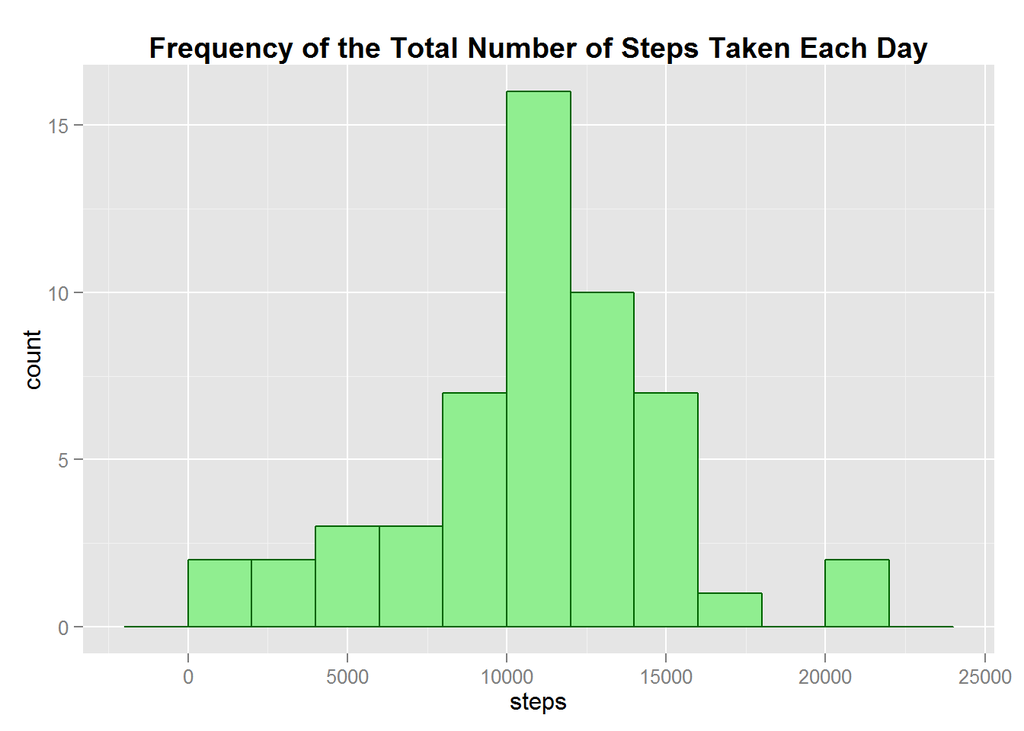

```r
# generate histogram (graphical representation of the distribution of data) of the total number of steps taken each day
library(ggplot2)
plot = ggplot(data=stepsPerDay, aes(x=steps))
plot = plot + geom_histogram(colour="darkgreen", fill="lightgreen", binwidth=2000)
plot = plot + ggtitle("Frequency of the Total Number of Steps Taken Each Day")
plot = plot + theme(plot.title = element_text(face="bold"))
plot
```

Given the frequency distribution appears normal, one would expect the mean and median to be relatively equal.

```r
# calculate the mean/median total number of steps taken per day
options(scipen=999)
stepsPerDayMean <- round(mean(stepsPerDay$steps))
stepsPerDaySD <- round(sd(stepsPerDay$steps))
stepsPerDayMedian <- median(stepsPerDay$steps)
```

The mean value for steps per day is 10766 with a standard deviation of 4269. The median value is 10765.

Calculating the mean for each time interval provides some idea of the distribution of steps over the course of the day.

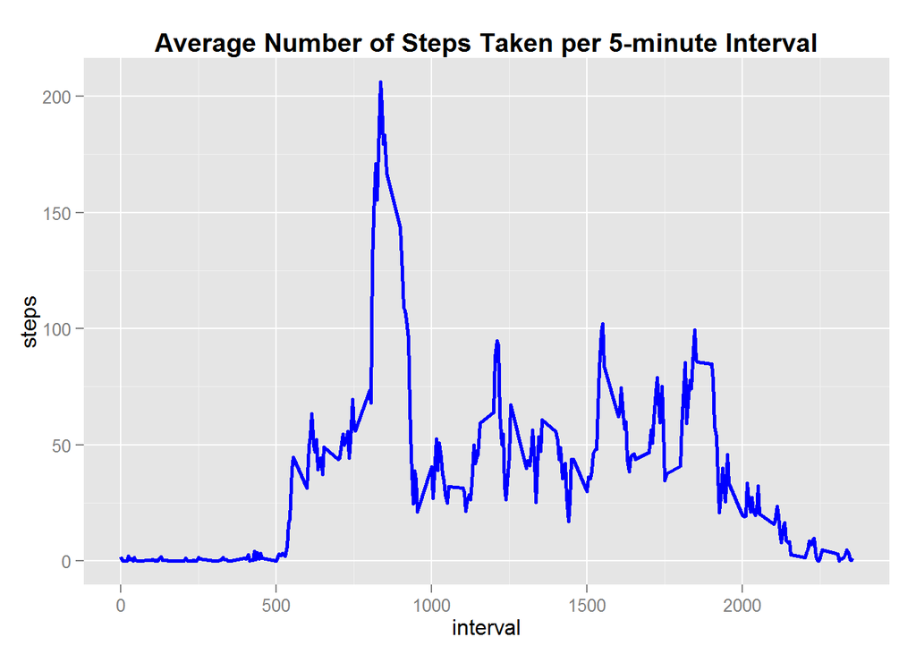

```r
# time series plot of the 5 minute interval (x-axis) and the average number of steps taken, averages across all days (y-axis)
plot1 = ggplot(data=stepsPerIntervalMean, aes(interval, steps))
plot1 = plot1 + geom_line(colour="blue", size=1)
plot1 = plot1 + ggtitle("Average Number of Steps Taken per 5-minute Interval")
plot1 = plot1 + theme(plot.title = element_text(face="bold"))
plot1
```

```r
# calculate the 5 minute interval that on average across all the days in the dataset contains the maximum number of steps
interalWithMostSteps <- stepsPerIntervalMean[stepsPerIntervalMean$steps==max(stepsPerIntervalMean$steps),"interval"]
```

The time interval with highest mean number of steps (that peak between 500 and 1000) is 835.

```r
# calculate and report the total number of missing values (total number of rows with NA)
numberOfNAs <- sum(is.na(stepsData$steps))
```

Unfortunately, the dataset contains 2304. If we replace the NAs with mean for that interval, will make it a difference?

```r
# replace NA with time interval mean
stepsDataMean <- read.csv("activity.csv", header=TRUE)
for (i in 1:nrow(stepsDataMean)) {
        if(is.na(stepsDataMean$steps[i])==TRUE) {
                stepsDataMean$steps[i] <- stepsPerIntervalMean$steps[stepsPerIntervalMean$interval == stepsDataMean$interval[i]]
        }
}
```

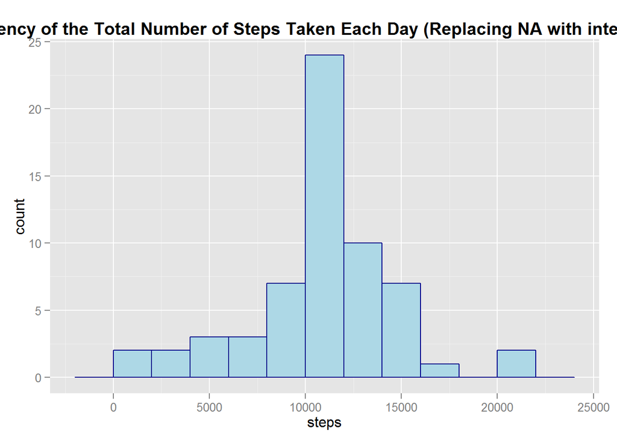

```r
# generate histogram (graphical representation of the distribution of data) of the total number of steps taken each day
stepsPerDay <- aggregate(steps ~ date, data=stepsDataMean, sum)
plot2 = ggplot(data=stepsPerDay, aes(x=steps))
plot2 = plot2 + geom_histogram(colour="darkblue", fill="lightblue", binwidth=2000)
plot2 = plot2 + ggtitle("Frequency of the Total Number of Steps Taken Each Day (Replacing NA with interval mean")
plot2 = plot2 + theme(plot.title = element_text(face="bold"))
plot2
```

```r
library(gridExtra)
```

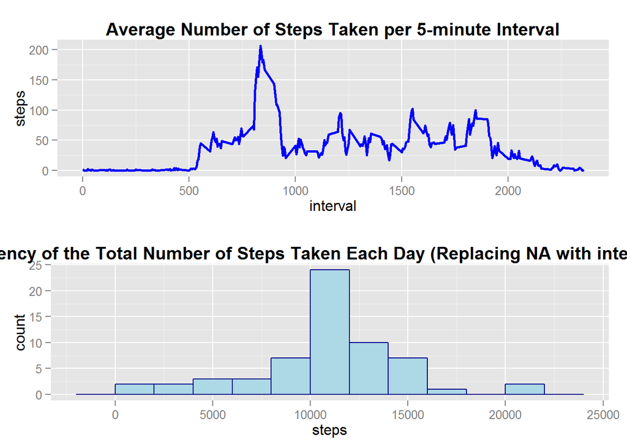

```r
grid.arrange(plot1, plot2)
```

The removeal of the datapoints narrows the distribution as represented by the mean and standard deviation.

```r
# calculate the mean/median total number of steps taken per day
stepsPerDayMeanNAsRemoved <- round(mean(stepsPerDay$steps))
stepsPerDaySDNAsRemoved <- round(sd(stepsPerDay$steps))
stepsPerDayMedianNAsRemoved <- round(median(stepsPerDay$steps))
```

Recall, the mean value for steps per day is 10766 with a standard deviation of 4269 for the dataset with NAs. After the replacements of the NAs, the mean value for steps per day is 10766 with a standard deviation of 3974. The median value is 10766.

Does this individual display different behaviours during the week than on the weekend?

```r
# create a new factor variable in the dataset with two levels - "weekday" and "weekend" indicating whether a given data is a weekday or weekend day
# opting to the mean as the imputation of choice
stepsDataMean$day <- weekdays(as.Date(stepsDataMean$date))
stepsDataMean$dayClassification <- ifelse(stepsDataMean$day=="Saturday" | stepsDataMean$day=="Sunday", "weekend", "weekday")

stepsPerIntervalMeanWeekday <- aggregate(steps ~ interval, data=subset(stepsDataMean,dayClassification=="weekday"), mean)
stepsPerIntervalMeanWeekend <- aggregate(steps ~ interval, data=subset(stepsDataMean,dayClassification=="weekend"), mean)
```

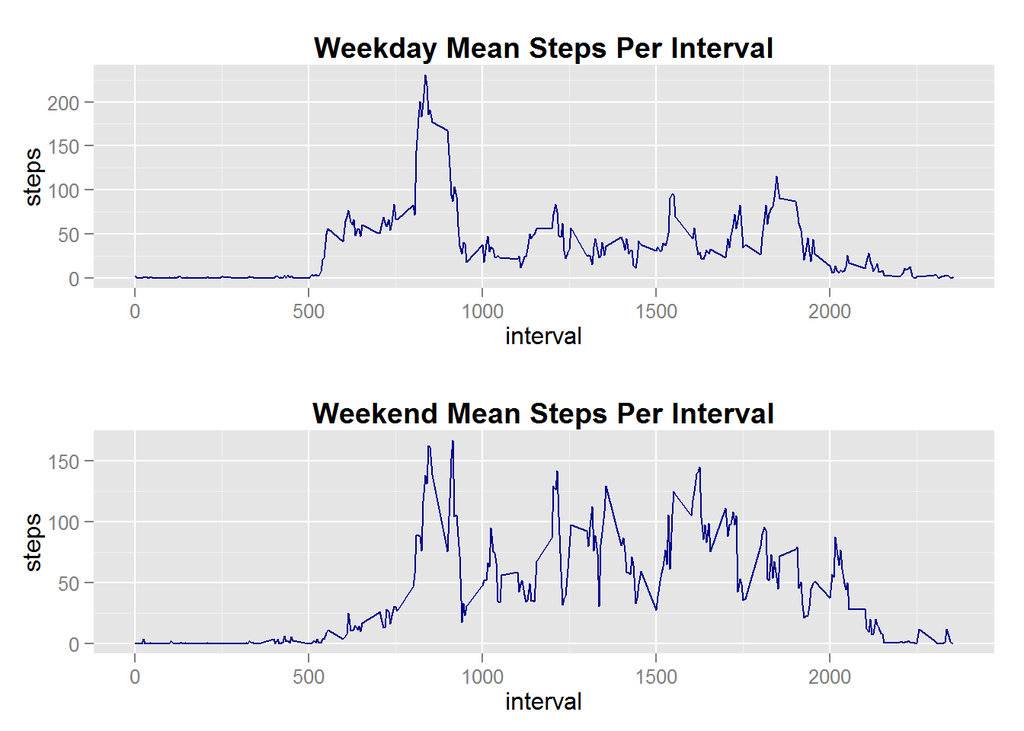

```r
plotWeekday = ggplot(data=stepsPerIntervalMeanWeekday, aes(x=interval,y=steps))
plotWeekday = plotWeekday + geom_line(colour="darkblue")
plotWeekday = plotWeekday + ggtitle("Weekday Mean Steps Per Interval")
plotWeekday = plotWeekday + theme(plot.title = element_text(face="bold"))

plotWeekend = ggplot(data=stepsPerIntervalMeanWeekend, aes(x=interval,y=steps))
plotWeekend = plotWeekend + geom_line(colour="darkblue")
plotWeekend = plotWeekend + ggtitle("Weekend Mean Steps Per Interval")
plotWeekend = plotWeekend + theme(plot.title = element_text(face="bold"))

grid.arrange(plotWeekday, plotWeekend)
```

Most certainly yes. The steps start and end later in the day.